# Traffic Collisions in NYC

Coleman Breen

September 21, 2018

```r
knitr::opts_chunk$set(echo = TRUE)
knitr::opts_chunk$set(warning = FALSE)
knitr::opts_chunk$set(message = FALSE)

library(tidyverse)
```

# New York City Traffic Collisions

In this analysis, we’ll be looking at traffic collisions in New York City. We’ll start by mapping locations to of collisions to get a sense of where accidents are happening.

## Which locations have high incidences of traffic collisions?

We’ll start by loading in the data and taking a look at it.

```r
nyc_df <- read_csv('NYPD_Motor_Vehicle_Collisions.csv')
```

This is a ton of information–over a million observations! Let’s start by mapping all of the observations, just to see if any pattern emerges. We’ll look at collisions based on zipcode.

```r
#--> Make variable name dplyr friendly
nyc_df <- rename(nyc_df, 'ZIP' = 'ZIP CODE')
```

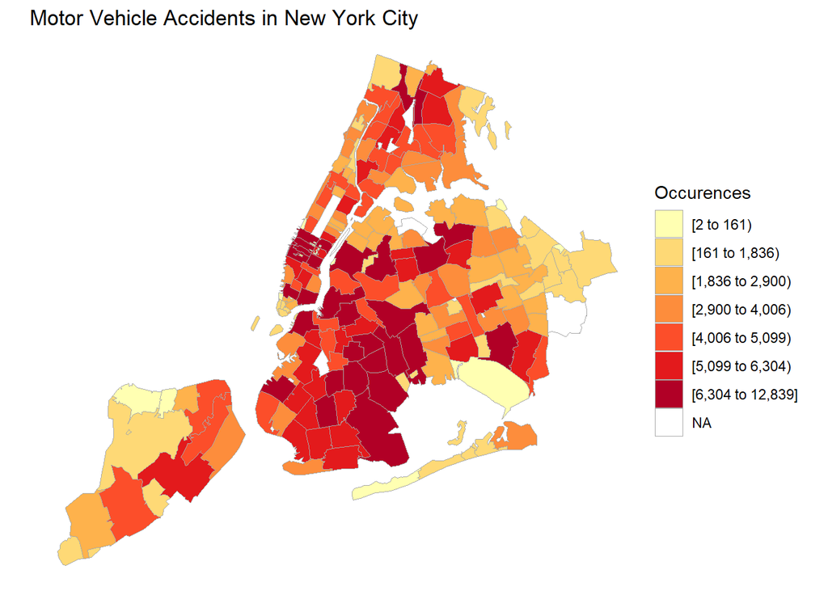

```r
library(ggplot2)
library(choroplethr)
library(choroplethrZip)

#-->How many accidnets are there per zip code
nyc_df %>%
  filter(!is.na(ZIP)) %>%
  count(ZIP) -> acc_by_zip_df

#--> Get data into the right form
acc_by_zip_df <- transmute(acc_by_zip_df, region = (ZIP), value = n)
acc_by_zip_df %>%
  mutate(region = as.character(region)) -> acc_by_zip_df

#--> Vector of NYC counties
nyc_counties <- c(36005, 36047, 36061, 36081, 36085)

#--> Alternate version
choro = ZipChoropleth$new(acc_by_zip_df)
choro$title = "Motor Vehicle Accidents in New York City"
choro$ggplot_scale = scale_fill_brewer(name = "Occurences", palette = "YlOrRd",
                                       drop = FALSE)
choro$set_zoom_zip(state_zoom = NULL, county_zoom = nyc_counties,  msa_zoom=NULL, zip_zoom=NULL)
choro$render()
```

## How are these high traffic collisions locations different at different times of the day?

Let’s take a look at the same map but broken into times of the day. We’ll split the day into four equal parts.

```r
library(lubridate)

nyc_df <- mutate(nyc_df, Hour = hour(TIME))

#--> Split by time
nyc_t1_df <- filter(nyc_df, Hour < 6)

nyc_df %>%
  filter(Hour >= 6) %>%
  filter(Hour < 12) -> nyc_t2_df

nyc_df %>%
  filter(Hour >= 12) %>%
  filter(Hour < 18) -> nyc_t3_df

nyc_df %>%
  filter(Hour >= 18) %>%
  filter(Hour < 24) -> nyc_t4_df
```

```r
#--> First set
#--> Go through the process of looking at hits by zip code (should refactor into function)
nyc_t1_df %>%
  filter(!is.na(ZIP)) %>%
  count(ZIP) -> t1_df

#--> Get data into the right form
t1_df <- transmute(t1_df, region = (ZIP), value = n)
t1_df %>%
  mutate(region = as.character(region)) -> t1_df

#--> Second set
#--> Go through the process of looking at hits by zip code (should refactor into function)
nyc_t2_df %>%
  filter(!is.na(ZIP)) %>%
  count(ZIP) -> t2_df

#--> Get data into the right form
t2_df <- transmute(t2_df, region = (ZIP), value = n)
t2_df %>%
  mutate(region = as.character(region)) -> t2_df
```

Break this into two code chunks to make a bit more readable.

```r
#--> Third set
#--> Go through the process of looking at hits by zip code (should refactor into function)
nyc_t3_df %>%
  filter(!is.na(ZIP)) %>%
  count(ZIP) -> t3_df

#--> Get data into the right form
t3_df <- transmute(t3_df, region = (ZIP), value = n)
t3_df %>%
  mutate(region = as.character(region)) -> t3_df

#--> Fourth set
#--> Go through the process of looking at hits by zip code (should refactor into function)
nyc_t4_df %>%
  filter(!is.na(ZIP)) %>%
  count(ZIP) -> t4_df

#--> Get data into the right form
t4_df <- transmute(t4_df, region = (ZIP), value = n)
t4_df %>%
  mutate(region = as.character(region)) -> t4_df
```

Now, make 4 maps (basically faceting by time of day).

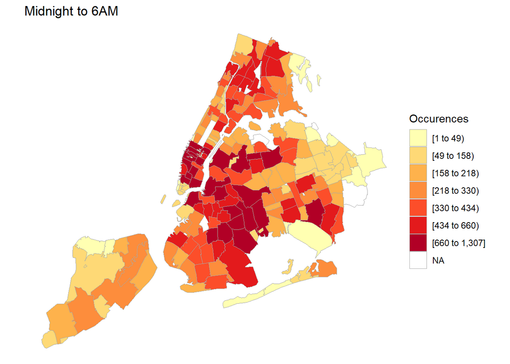

```r
#--> Free up some RAM
rm(nyc_t1_df, nyc_t2_df, nyc_t3_df, nyc_t4_df)

#--> Number 1
choro1 = ZipChoropleth$new(t1_df)
choro1$title = "Midnight to 6AM"
choro1$ggplot_scale = scale_fill_brewer(name = "Occurences", palette = "YlOrRd",
                                       drop = FALSE)
choro1$set_zoom_zip(state_zoom = NULL, county_zoom = nyc_counties,  msa_zoom=NULL, zip_zoom=NULL)
choro1$render()
```

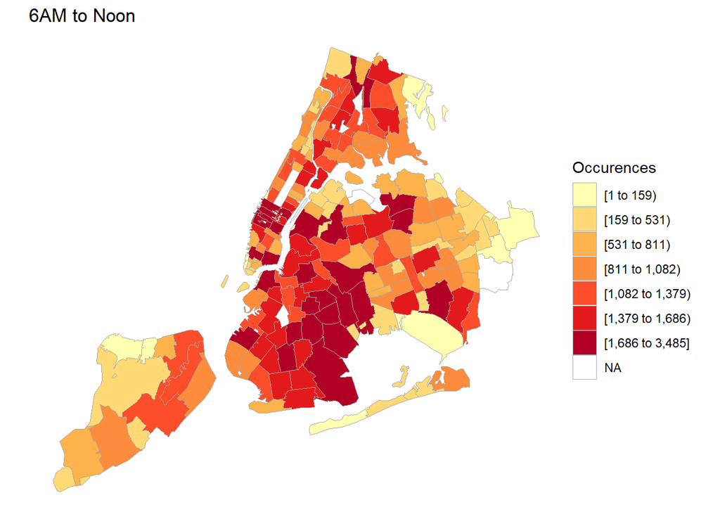

```r
#--> Number 2
choro2 = ZipChoropleth$new(t2_df)
choro2$title = "6AM to Noon"
choro2$ggplot_scale = scale_fill_brewer(name = "Occurences", palette = "YlOrRd",
                                       drop = FALSE)
choro2$set_zoom_zip(state_zoom = NULL, county_zoom = nyc_counties,  msa_zoom=NULL, zip_zoom=NULL)
choro2$render()
```

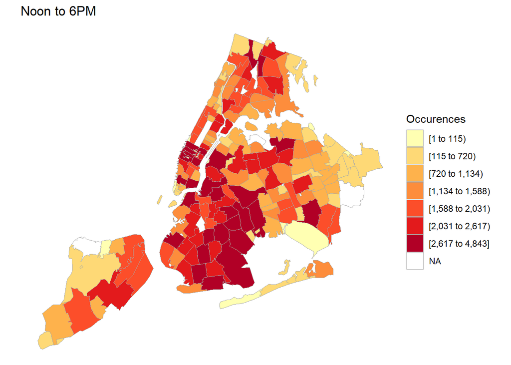

```r
#--> Number 3
choro3 = ZipChoropleth$new(t3_df)
choro3$title = "Noon to 6PM"
choro3$ggplot_scale = scale_fill_brewer(name = "Occurences", palette = "YlOrRd",
                                       drop = FALSE)
choro3$set_zoom_zip(state_zoom = NULL, county_zoom = nyc_counties,  msa_zoom=NULL, zip_zoom=NULL)
choro3$render()
```

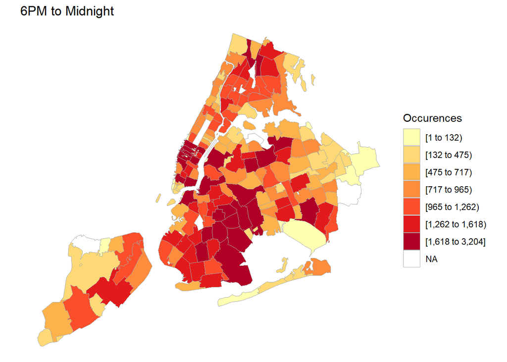

```r
#--> Number 4
choro4 = ZipChoropleth$new(t4_df)
choro4$title = "6PM to Midnight"
choro4$ggplot_scale = scale_fill_brewer(name = "Occurences", palette = "YlOrRd",
                                       drop = FALSE)
choro4$set_zoom_zip(state_zoom = NULL, county_zoom = nyc_counties,  msa_zoom=NULL, zip_zoom=NULL)
choro4$render()
```

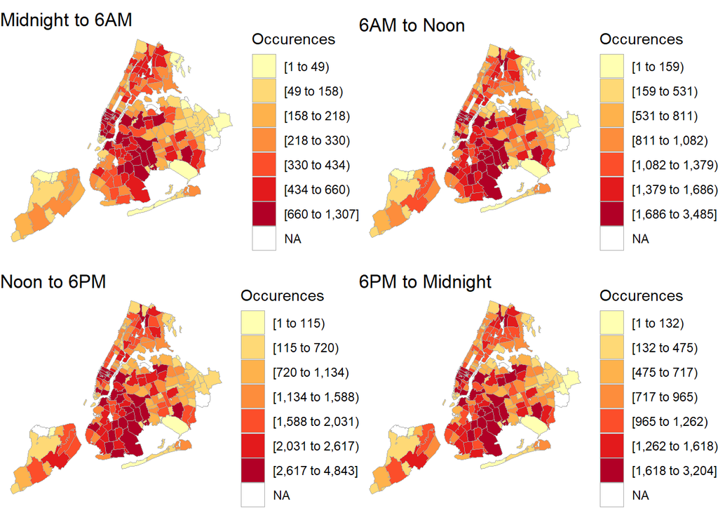

```r
library(gridExtra)
grid.arrange(choro1$render(), choro2$render(), choro3$render(), choro4$render(), nrow=2)
```

To make this better, I could scale the color axis and make it so that each zip code has a certain percentage of accidents instead of raw counts. We could also look at accidents that are fatal and non-fatal and see if there are hot spots there.

## Visualise the correlation between home values in a block group and traffic collisions

I’m pulling data from [Zillow](https://www.zillow.com/research/data/).

```r
#--> Read in data
home_price_df <- read_csv('home_prices_by_zip.csv')
data(df_pop_zip)

home_price_df %>%
  transmute(region = as.character(RegionName), value = (PeakZHVI %/% 1000)) %>%
  filter(region %in% df_pop_zip$region) -> home_price_df
head(home_price_df)
```

```
## # A tibble: 6 x 2
##   region value
##   <chr>  <dbl>
## 1 10025   1141
## 2 60657    352
## 3 10023   1623
## 4 77494    336
## 5 60614    429
## 6 79936    132
```

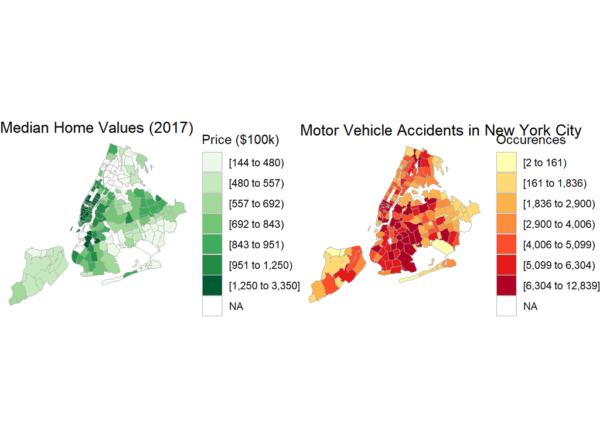

```r
choroPrice = ZipChoropleth$new(home_price_df)
choroPrice$title = "Median Home Values (2017)"
choroPrice$ggplot_scale = scale_fill_brewer(name = "Price ($100k)", palette = "Greens",
                                       drop = FALSE)
choroPrice$set_zoom_zip(state_zoom = NULL, county_zoom = nyc_counties,  msa_zoom=NULL, zip_zoom=NULL)

library(gridExtra)
grid.arrange(choroPrice$render(), choro$render(), nrow = 1)
```

There is no clear relationship between home value and prevelance of car accidents that I can see from this visualization. Let’s create a scatter plot to look.

[figure not shown]

```r
full_join(df_pop_zip, home_price_df, by = "region") %>%
  ggplot(aes(x = value.x, y = value.y)) +
  geom_point() +
  geom_smooth(method = 'lm') +
  xlab('Number of Motor Vehicle Collisions') +
  ylab('Median Home Value (2017)') +
  ggtitle('Home Value and Car Accidents')
```